# Using the contact package

### Section 2.) Creating polygon-intersection-based direct-contacts network using point-location data

Here, we show how to create contact networks detailing the number of direct, physical contacts between tracked individuals. We derive polygons represntative of animals’ physical space from point-locations. We then define “contact” as occuring when polygons intersect (i.e., SpTh == 0). However, we re-define this SpTh to account for RTLS accuracy using the findDistThresh function below.

The steps for direct-contact-network creation are described below.

**A.) Subset calves2018 and ensure all required columns exist in the calves data set (i.e., xy coordinates, unique individual IDs, dateTime).**

**B.) Clean and filter the data set.**

**C.) Temporally smooth point-locations, ensuring that animals are observed at identical timepoints (Note: this was an unnecessary step in Section 1 because the water trough’s location was fixed and unchanging over time).**

**D.) Derive calf head and body polygons from point locations.**

Note: This is done using a novel methodology described in detail in a manuscript currently under review for publication in *Ecology and Evolution* (the same manuscript in which we introduce this package to the scientific community). Our methodology is briefly outlined by the figure below.

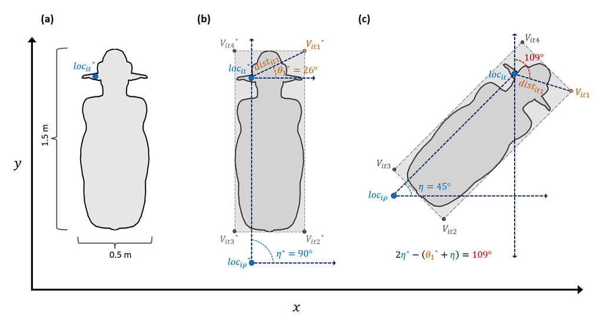

*Steps for deriving polygons representing calf physical space. (a) Create a planar model describing the physical dimensions of the animal, and denote where where tracking devices (i.e., loc(it)-star) exist on the individual’s body. Note that “star” designations differentiate planar-model parameters from their empirical counterparts, and that eta-star is used to describe the orientation of this model (b) Describe the location of each vertex, V(itl)-star, exists relative to loc(it)-star. Here, we use V(it1)-star as a specific example. (c) Using the relative location information ascribed to each vertex in the planar model, interpolate empirical vertex coordinates, {V(it)}, while accounting for angular direction of observed movements (eta). Thus, point-location transformations maintain observed angular orientations for individuals’ movement paths.*

**E.) Calculate inter-animal distances at each time step.**

**F.) Identify what SpTh value will allow us to capture 99% of contacts, polygon intersections, given the RTLS accuracy.**

**G.) Identify time points when calf heads were within the re-adjusted SpTh distance from one another or body polygons.**

**H.) Visualize the contact networks with edgeweights weighted according to number of observed contacts.**

```r
data("calves2018") #load the data set
```

**A.) Subset calves2018 and ensure all required columns exist in the calves data set (i.e., xy coordinates, unique individual IDs, dateTime)**

```r
head(calves2018) #see that all necessary columns are there.
```

```
#>         calftag     x      y   dateTime
#> 2694575     598 42.77 181.85 2018-06-01
#> 2694576     570 38.74 192.62 2018-06-01
#> 2694577     577 29.44 181.43 2018-06-01
#> 2694578     688 47.83 182.02 2018-06-01
#> 2694580     651 50.08 171.50 2018-06-01
#> 2694581     575 26.31 185.82 2018-06-01
```

We will only look at points from the 1st date represented in the data set (06/01/2018). Therefore, we need to get the unique date values in the data.

```r
calves2018$date<-lubridate::date(calves2018$dateTime) #add the date column to the data set

calves06012018 <- droplevels(subset(calves2018, date == unique(calves2018$date)[1])) #pull the observations from 06/01/2018
```

**B.) Clean and filter the data set.**

Here we run the various spatiotemporal-data-filtering functions offered by the package (i.e., mps, confine, dup). We run them in this particular order because one filtration process may trigger others to remove points that are not necessariliy erroneous. For example, removing duplicated point-locations could create a situation where it appears that individuals moved at a speed exceeding a specified mps threshold. Thus, in this scenario, subsequently running the mps function may remove points that would not have been flagged for removal prior to removing duplicated points.

First, we ensure that points do not represent impossible/highly unlikely movement speeds.

```r
system.time(calves_filter1 <- contact::mps(calves06012018, id = calves06012018$calftag, point.x = calves06012018$x, point.y = calves06012018$y, dateTime = calves06012018$dateTime, mpsThreshold = 10, lonlat = FALSE, parallel = FALSE, filterOutput = TRUE)) #we assume that if calves' point-locations suggest they moved faster than 10m/s, points are erroneous and should be removed. #This did not remove any observations.
```

```
#>    user  system elapsed
#>   4.167   0.098   4.380
```

Now we want to ensure that all points are within the specific feedlot pen boundaries. As calves could not escape fedlot pens, points outside the pen or adjacent feed bunks are erroneous.

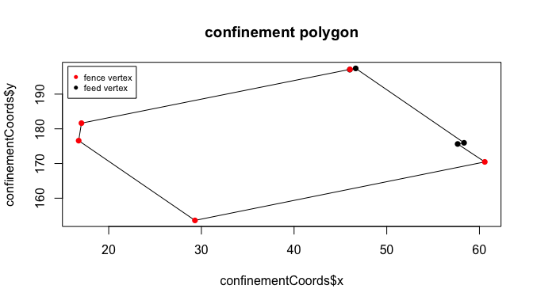

```r
confinementCoords <- data.frame(object = c("feed", "feed", "feed", "feed","fence", "fence", "fence", "fence", "fence"), x = c(46.0118, 46.6482, 58.3415, 57.6507, 60.5775, 29.3054, 16.7602, 17.0590, 46.0309), y = c(197.0570, 197.4131, 175.9618, 175.6284, 170.4628, 153.6002, 176.5861, 181.6315, 197.1261)) #these are the x & y coordinates for the feedlot-pen fenceline and adjacent feedbunk vertices. Note that they are arranged in a clockwise order, as the confine function below requires input vertices to be ordered clockwise or counter-clockwise.

{plot(confinementCoords$x,confinementCoords$y, col = confinementCoords$object, lines(c(confinementCoords$x, confinementCoords$x[1]),c(confinementCoords$y, confinementCoords$y[1])), pch=16, main = "confinement polygon")
 legend(15.6, 198, col = c(2,1), legend = c("fence vertex", "feed vertex"), cex = 0.7, pch = 16)} #this is what the pen outline looks like.
```

```r
system.time(calves_filter2<-contact::confine(calves_filter1, point.x = calves_filter1$x, point.y = calves_filter1$y, confinementCoord.x = confinementCoords$x, confinementCoord.y = confinementCoords$y, filterOutput = TRUE)) #this removed an additional 1784 observations
```

```
#>    user  system elapsed
#>   0.091   0.003   0.095
```

Finally, we want to remove duplicate observations. This is an important step because many data-processing functions below require that no duplicates exist.

```r
system.time(calves_filter3<- contact::dup(calves_filter2, id = calves_filter2$calftag, point.x = calves_filter2$x, point.y = calves_filter2$y, dateTime = calves_filter2$dateTime, avg = FALSE, parallel = FALSE, filterOutput = TRUE)) #it looks like there were no duplicates to remove in the first place. We're ready to proceed with analyses.
```

```
#>    user  system elapsed
#>   0.319   0.012   0.331
```

**C.) Temporally smooth point-locations, ensuring that animals are observed at identical timepoints**

Note: This was an unnecessary step in Section 1 because the water trough’s location was fixed and unchanging over time.

```r
#create our data set that shows calves average position every 10 seconds
system.time(calves.10secSmoothed <- contact::tempAggregate(x = calves_filter3, id = calves_filter3$calftag, point.x = calves_filter3$x, point.y = calves_filter3$y, dateTime = calves_filter3$dateTime, secondAgg = 10, extrapolate.left = FALSE, resolutionLevel = "reduced", extrapolate.right = FALSE, na.rm = TRUE, smooth.type = 2))
```

```
#>    user  system elapsed
#>   9.236   0.347   9.619
```

Note that we set na.rm to TRUE and resolutionLevel to “reduced” here. This means that temporal intervals between observed relocations may not necessarily be equidistant, as when individuals were not observed at a given time point, they are removed from the data set (rather than introducing an NA instead). This speeds up later processing functions (because the size of calves.10secSmoothed is relatively small). Please note, however, that having equidistant temporal intervals between observed relocations is a requirement for some contact-function processes (e.g., the path-randomization procedure based on Spiegel *et al.* 2016 methods that can be implemented using contact::randomizePaths). Thus, before these specific processes can be run, the data set must be re-processed with na.rm == FALSE.

**D.) Derive calf head and body polygons from point locations.**

We could transform empirical point-locations into polygon vertices one vertex at a time by repeatedly using the repositionReferencePoint function, but the referencePoint2Polygon function provides an expediant shortcut for generating square/rectangular polygons from point-locations. Moving forward, we assume that calves’ body sizes are equivalent and stable, and that 0.333 m X 0.333 and 1.167 m X 0.5 m polygons accurately represent areas where calves’ heads and bodies exist, respectively.

```r
##Create 0.333 m X 0.333 m calf head polygons.
#Note that this is done using the original reference points, which denote the locations of RFID tags on individuals' left ears.
system.time(calf_heads <- contact::referencePoint2Polygon(x = calves.10secSmoothed, id = calves.10secSmoothed$id, dateTime = calves.10secSmoothed$dateTime, point.x = calves.10secSmoothed$x, point.y = calves.10secSmoothed$y, direction = NULL, StartLocation = "DL", UpDownRepositionLen = 0.333, LeftRightRepositionLen = 0.333, CenterPoint = FALSE, MidPoints = FALSE, immobThreshold = 0, parallel = FALSE, modelOrientation = 90)) #Note that we do not specify an immobility threshold here. This is because the head polygons will later be unioned with body polygons generated from different point-locations, and prematurely thresholding them will potentially cause misalignment between the two polygons.
```

```
#>    user  system elapsed
#>   9.639   0.934  11.060
```

```r
head(calf_heads)
```

```
#>    id cornerPoint1.x cornerPoint1.y cornerPoint2.x cornerPoint2.y
#> 1 570         38.535        192.444             NA             NA
#> 2 570         37.953        192.218       37.64258       192.0975
#> 3 570         37.292        191.094       37.12320       190.8070
#> 4 570         37.414        190.356       37.46831       190.0275
#> 5 570         37.829        191.362       37.95599       191.6698
#> 6 570         37.930        192.200       37.96985       192.5306
#>   cornerPoint3.x cornerPoint3.y cornerPoint4.x cornerPoint4.y
#> 1             NA             NA             NA             NA
#> 2       37.52204       192.4079       37.83246       192.5284
#> 3       36.83615       190.9758       37.00496       191.2628
#> 4       37.13977       189.9731       37.08546       190.3017
#> 5       38.26383       191.5428       38.13684       191.2350
#> 6       38.30045       192.4908       38.26061       192.1602
#>   startLocation movementDirection upDownRepositionLength
#> 1            DL                NA                  0.333
#> 2            DL         201.22200                  0.333
#> 3            DL         239.54114                  0.333
#> 4            DL         279.38677                  0.333
#> 5            DL          67.58264                  0.333
#> 6            DL          83.12757                  0.333
#>   leftRightRepositionLength immob immobThreshold            dateTime dt
#> 1                     0.333    NA              0 2018-06-01 00:00:00 10
#> 2                     0.333     0              0 2018-06-01 00:00:10 10
#> 3                     0.333     0              0 2018-06-01 00:00:20 10
#> 4                     0.333     0              0 2018-06-01 00:00:30 10
#> 5                     0.333     0              0 2018-06-01 00:00:40 10
#> 6                     0.333     0              0 2018-06-01 00:00:50 10
```

When creating the head polygons, we set direction == NULL because we do not have gyroscopic data detailing movement directions associated with each relocation event. Thus, polygons are subject to the assumptions pertaining to deriving polygons from point-locations as described by Farthing *et al.* (in Review). (*see* the contact::referencePoint2Polygon help page for a brief description of these assumptions).

Note that the referencePoint2Polygon function assumes the input point-locations represent a single vertex of desired polygons. Because calves’ heads are not the same width as their bodies (i.e., 1.167 m X 0.5 m ; L X W), and are assumed to be centered at the front of the body, however, we must move reference points (on the left ear) to the left by 0.0835 m to reposition them at the upper-left corner of calves bodies before creating body polygons. Additionally, note that we are assuming ears are parallel to shoulder-tips.

```r
system.time(leftShoulder.point<-contact::repositionReferencePoint(x = calves.10secSmoothed, id = calves.10secSmoothed$id, dateTime = calves.10secSmoothed$dateTime, point.x = calves.10secSmoothed$x, point.y = calves.10secSmoothed$y, direction = NULL, repositionAngle = 180, repositionDist = 0.0835, immobThreshold = 0, parallel = FALSE, modelOrientation = 90))  #Again, see that we do not specify a immobility threshold here.
```

```
#>    user  system elapsed
#>  10.723   0.838  11.593
```

Now we have the left-shoulder points, but before we create the bodies, let’s take examine these new points more closely.

```r
head(leftShoulder.point)
```

```
#>    id x.original y.original dist.original dx.original dy.original
#> 1 570     38.535    192.444     0.6243397      -0.582      -0.226
#> 2 570     37.953    192.218     1.3039544      -0.661      -1.124
#> 3 570     37.292    191.094     0.7480160       0.122      -0.738
#> 4 570     37.414    190.356     1.0882376       0.415       1.006
#> 5 570     37.829    191.362     0.8440646       0.101       0.838
#> 6 570     37.930    192.200     0.8508819       0.420       0.740
#>   x.adjusted y.adjusted dist.adjusted dx.adjusted dy.adjusted
#> 1         NA         NA            NA          NA          NA
#> 2   37.98323   192.1402     1.2523101 -0.61924909  -1.0884903
#> 3   37.36398   191.0517     0.6947865  0.13240548  -0.6820535
#> 4   37.49638   190.3696     1.0555939  0.25542813   1.0242241
#> 5   37.75181   191.3938     0.8216927  0.09528989   0.8161488
#> 6   37.84710   192.2100     0.8831360  0.43028128   0.7712245
#>   movementDirection repositionAngle repositionDist immob immobThreshold
#> 1                NA             180         0.0835    NA              0
#> 2         201.22200             180         0.0835     0              0
#> 3         239.54114             180         0.0835     0              0
#> 4         279.38677             180         0.0835     0              0
#> 5          67.58264             180         0.0835     0              0
#> 6          83.12757             180         0.0835     0              0
#>              dateTime dt
#> 1 2018-06-01 00:00:00 10
#> 2 2018-06-01 00:00:10 10
#> 3 2018-06-01 00:00:20 10
#> 4 2018-06-01 00:00:30 10
#> 5 2018-06-01 00:00:40 10
#> 6 2018-06-01 00:00:50 10
```

See that moving the points changed the calculated dx,dy values from those associated with empirical data points. Therefore, movement angles calculated from these data points will differ from values calculated using the empirical observations. Because of that, when creating body polygons, we must specify that the function use angle values from the empirical data set. Luckily, the function allows for this very easily.

Additionally, the differing calculated-distance values will potentially cause misalignment errors when unioning the head and body polygons if either is created with a specified immobility threshold (*see* referencePoint2Polygon help page). As outlined by Farthing *et al.* (in Review), in the absence of accompanying gyroscopic data, movement angles are calculated based on observed relocation events with the assumption that all individuals are forward-facing when moving. Thus, specifying an immobility threshold (i.e., observed relocation distance required for us to state that movement actually occurred) is necessary to reduce directional errors by discounting observed movements so miniscule that the majority of the modeled physical-space is likely unaffected (e.g., head shaking), and therefore would not be repositioned. Thus, prior to unioning the polygons, we will not implement an immobility threshold.

Moving forward, let’s generate the vertices for calves’ anterior- and posterior-body polygons (i.e., we’re dividing body polygons into two halves). Rather than running the referencePoint2Polygon function twice, we instead set MidPoints = TRUE, which will effectively identify vertices for the bottom of anterior body sections/top of posterior ones.

```r
system.time(calf_bods <- contact::referencePoint2Polygon(x = leftShoulder.point, id = leftShoulder.point$id, dateTime = leftShoulder.point$dateTime, point.x = leftShoulder.point$x.adjusted, point.y = leftShoulder.point$y.adjusted, direction = leftShoulder.point$movementDirection, StartLocation = "UL", UpDownRepositionLen = 1.167, LeftRightRepositionLen = 0.5, CenterPoint = FALSE, MidPoints = TRUE, immobThreshold = 0, parallel = FALSE, modelOrientation = 90)) #note that direction == leftShoulder.point$movementDirection.
```

```
#>    user  system elapsed
#>   9.143   0.838  10.015
```

```r
head(calf_bods) #notice the additional columns compared to calf_heads
```

```
#>    id cornerPoint1.x cornerPoint1.y midPoint1.x midPoint1.y cornerPoint2.x
#> 1 570             NA             NA          NA          NA             NA
#> 2 570       37.98323       192.1402    37.89273    192.3732       37.80223
#> 3 570       37.36398       191.0517    37.14848    191.1784       36.93298
#> 4 570       37.49638       190.3696    37.24973    190.3288       37.00308
#> 5 570       37.75181       191.3938    37.98292    191.2985       38.21403
#> 6 570       37.84710       192.2100    38.09530    192.1801       38.34351
#>   cornerPoint2.y midPoint2.x midPoint2.y cornerPoint3.x cornerPoint3.y
#> 1             NA          NA          NA             NA             NA
#> 2       192.6063    38.34616    192.8175       38.89009       193.0287
#> 3       191.3051    37.22877    191.8081       37.52455       192.3111
#> 4       190.2881    36.90791    190.8638       36.81274       191.4394
#> 5       191.2032    37.99151    190.6638       37.76899       190.1244
#> 6       192.1502    38.27369    191.5709       38.20387       190.9915
#>   midPoint3.x midPoint3.y cornerPoint4.x cornerPoint4.y midPoint4.x
```

[output cut: 20 more lines]

Now we can take vertices from calf_heads and calf_bods, and create a vertex set {V(it)} delineating the calves full bodies (i.e., we essentially union the calf_heads and calf_bod polygons). Note that in this calf_FullBody data frame, vertex1 is located on calves left shoulders, and vertices are ordered in a clockwise direction from that point.

```r
calf_FullBody <- data.frame(calf_id = calf_bods$id, vertex1.x = calf_bods$cornerPoint1.x, vertex1.y = calf_bods$cornerPoint1.y, vertex2.x = calf_heads$cornerPoint1.x, vertex2.y = calf_heads$cornerPoint1.y, vertex3.x = calf_heads$cornerPoint2.x, vertex3.y = calf_heads$cornerPoint2.y, vertex4.x = calf_heads$cornerPoint3.x, vertex4.y = calf_heads$cornerPoint3.y, vertex5.x = calf_heads$cornerPoint4.x, vertex5.y = calf_heads$cornerPoint4.y, vertex6.x = calf_bods$cornerPoint2.x, vertex6.y = calf_bods$cornerPoint2.y,  vertex7.x = calf_bods$midPoint2.x, vertex7.y = calf_bods$midPoint2.y, vertex8.x = calf_bods$cornerPoint3.x, vertex8.y = calf_bods$cornerPoint3.y, vertex9.x = calf_bods$cornerPoint4.x, vertex9.y = calf_bods$cornerPoint4.y, vertex10.x = calf_bods$midPoint4.x, vertex10.y = calf_bods$midPoint4.y, dateTime = calf_bods$dateTime)

head(calf_FullBody)
```

```
#>   calf_id vertex1.x vertex1.y vertex2.x vertex2.y vertex3.x vertex3.y
#> 1     570        NA        NA    38.535   192.444        NA        NA
#> 2     570  37.98323  192.1402    37.953   192.218  37.64258  192.0975
#> 3     570  37.36398  191.0517    37.292   191.094  37.12320  190.8070
#> 4     570  37.49638  190.3696    37.414   190.356  37.46831  190.0275
#> 5     570  37.75181  191.3938    37.829   191.362  37.95599  191.6698
#> 6     570  37.84710  192.2100    37.930   192.200  37.96985  192.5306
#>   vertex4.x vertex4.y vertex5.x vertex5.y vertex6.x vertex6.y vertex7.x
#> 1        NA        NA        NA        NA        NA        NA        NA
#> 2  37.52204  192.4079  37.83246  192.5284  37.80223  192.6063  38.34616
#> 3  36.83615  190.9758  37.00496  191.2628  36.93298  191.3051  37.22877
#> 4  37.13977  189.9731  37.08546  190.3017  37.00308  190.2881  36.90791
#> 5  38.26383  191.5428  38.13684  191.2350  38.21403  191.2032  37.99151
#> 6  38.30045  192.4908  38.26061  192.1602  38.34351  192.1502  38.27369
#>   vertex7.y vertex8.x vertex8.y vertex9.x vertex9.y vertex10.x vertex10.y
#> 1        NA        NA        NA        NA        NA         NA         NA
#> 2  192.8175  38.89009  193.0287  39.07109  192.5626   38.52716   192.3514
#> 3  191.8081  37.52455  192.3111  37.95555  192.0576   37.65976   191.5546
#> 4  190.8638  36.81274  191.4394  37.30605  191.5210   37.40121   190.9453
#> 5  190.6638  37.76899  190.1244  37.30677  190.3150   37.52929   190.8544
#> 6  191.5709  38.20387  190.9915  37.70746  191.0514   37.77728   191.6307
#>              dateTime
#> 1 2018-06-01 00:00:00
#> 2 2018-06-01 00:00:10
#> 3 2018-06-01 00:00:20
#> 4 2018-06-01 00:00:30
#> 5 2018-06-01 00:00:40
#> 6 2018-06-01 00:00:50
```

This is what an example of a calf full-body polygon looks like.

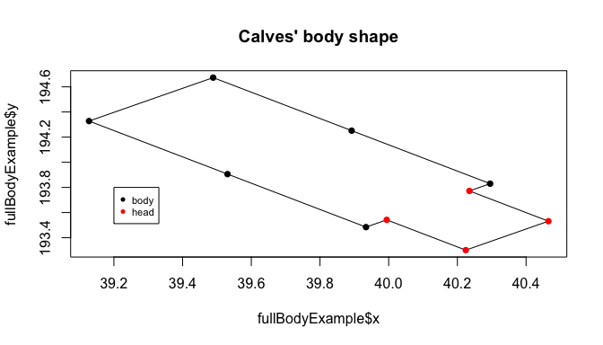

```r
fullBodyExample <- data.frame(section = c("body", rep("head", 4), rep("body", 5)), x = unname(unlist(calf_FullBody[10,c(seq(2,21, by =2))])), y = unname(unlist(calf_FullBody[10,c(seq(3,21, by =2))])))

{plot(fullBodyExample$x,fullBodyExample$y, col = fullBodyExample$section, lines(c(fullBodyExample$x, fullBodyExample$x[1]),c(fullBodyExample$y, fullBodyExample$y[1])), pch=16, main = "Calves' body shape")
 legend(39.2, 193.8, col = c(1,2), legend = c("body", "head"), cex = 0.7, pch = 16)}
```

Recall that these polygons were created without specifying immobility threshold values.

For reference, we show an example of a misalignment that may occur when enforcing an immobility threshold of 0.1m for head and body polygons prior to unioning them. Note that this is the same polygon that was shown above (i.e., same individual at the same time step).

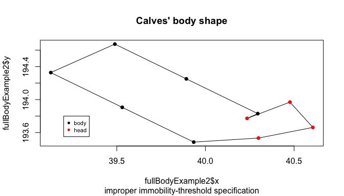

So, even when polygons are ultimately derived from the same empirical data, it’s clear that repositioning the reference point-locations to create different polygons does not allow for the implementation of immobility thresholds prior to unioning procedures.

We are still interested in reducing directional errors by implementing this threshold, however. We can do that now with a simple for-loop.

```r
immobility.vec<- (which(leftShoulder.point$dist.original < 0.1) + 1) #create a vector describing which polygons in calf_heads2 moved < 0.1m. Note that we add 1 to returned values because leftShoulder.point$dist.original details the distance to the successive point, but we want distance to the proceeding point.
calf_FullBody.immob<-calf_FullBody

for(i in immobility.vec){ #this can be a bit slow due to the length of the data sets, but a simple apply function is not appropriate here because rows must be updated sequentially. The within-function immobility-evaluating sub-function is much more efficient, but much larger and more unwieldy than this.
  calf_FullBody.immob[i,2:21] <- calf_FullBody[(i-1),2:21] #replace i-th observations in calf_FullBody with the preceding coordinates.
}
```

Now that we have defined the (x,y) coordinates for the full-body vertex set {V(it)}, we can use these polygons to generate contact networks. Before we move on, however, we will briefly mention another aspect of polygon-derivation that may also introduce movement-orientation error into the data set. As we note on the referencePoint2Polygon help page, in the absence of accompanying gyroscopic-movement data, under normal circumstances we would consider removing observations from our vertex set that represent movements outside of a pre-determined dt (i.e., length of time between consecutive relocation events) threshold. This would be done to ensure that relocation intervals are sufficiently small to minimize chances that animals face unknown directions between observed relocations. For the purposes of this vignette, however, we will assume that the dt-introduced errors are irrelevant.

**E.) Calculate inter-animal distances at each time step.**

The first step to network creation is calculating the distance between calves at each time step.

Note: the dist2All_df does not allow NA values in polygon coordinates (recall that the polygon derivation process introduced some NAs). Before running this function, we must remove these NA coordinates.

```r
naObs<-which(is.na(calf_FullBody.immob$vertex10.x) == T) #by identifying where NAs were introduced for any body vertex (other than vertex 1, which was left-shoulder point used to generate other vertices), we can determine what rows to remove. Note: we use a body vertex because two NAs were introduced (i.e., one from left-shoulder repositioning and another from polygon creation), as opposed to only one.

FullBody_noNAs<-droplevels(calf_FullBody.immob[-naObs,]) #remove NA coordinates
```

Now we can proceed with calculating inter-animal distances.

```r
system.time(fullbody_distances<-contact::dist2All_df(x = FullBody_noNAs, id = FullBody_noNAs$calf_id, dateTime = FullBody_noNAs$dateTime, point.x = NULL, point.y = NULL, poly.xy = FullBody_noNAs[,2:21], elev = NULL, parallel = FALSE, dataType = "Polygon", lonlat = FALSE, numVertices = 10)) #these are the distances from the nearest polygon edges (i.e., not distance from centroids).

head(fullbody_distances) #note that if individuals were not observed in the data at a specific time, the function reports NAs for their respective distances.
```

**F.) Identify what SpTh value will allow us to capture 99-percent of contacts, polygon intersections, given the RTLS accuracy.**

We initially define “contact” as occurring when two polygons intersect (i.e., SpTh = 0) on any given time step. As we did in Section 1, however, we want to account for RTLS positional accuracy by sampling from a multivariate distribution. Thus, here we seek to determine what SpTh value will likely capture 99-percent of contacts, defined as polygon intersections, and re-define “contact” accordingly.

```r
system.time(polySpThValues<-contact::findDistThresh(n1 = 1000, n2 = 1000, acc.Dist1 = 0.5, acc.Dist2 = NULL, pWithin1 = 90, pWithin2 = NULL, spTh = 0)) #spTh represents the initially-defined spatial threshold for contact

polySpThValues #it looks like an adjusted SpTh value of approximately 0.56 m will likely capture 99% of contacts, defined as instances when point-locations were within 0 m of one another, given the RTLS accuracy. #Note that because these confidence intervals are obtained from distributions generated from random samples, every time this function is run, results will be slightly different.

polyCI_99<-unname(polySpThValues[21]) #we will use this SpTh value moving forward.
```

**G.) Identify time points when calf heads were within the re-adjusted SpTh distance from one another or body polygons.**

```r
system.time(calf_fullBody_contacts <- contact::contactDur.all(fullbody_distances,dist.threshold=polyCI_99,sec.threshold=10, blocking = FALSE, equidistant.time = FALSE, parallel = FALSE, reportParameters = TRUE)) #Note that because we are not interested in making a time-aggregated network with > 1 temporal levels, we set blocking = FALSE to reduce processing time.
```

**H.) Visualize the contact networks with edgeweights weighted according to number of observed contacts.**

```r
#Generate a static network edge set (aggregated to the day resolution)
system.time(fullBody_edges<- contact::ntwrkEdges(x = calf_fullBody_contacts, importBlocks = FALSE, removeDuplicates = TRUE))

#visualize the network
fullBody.network <- igraph::simplify(igraph::graph_from_data_frame(d=fullBody_edges, directed=F),remove.multiple = T, remove.loops = T) #create network

igraph::V(fullBody.network)$color<- "orange1"
igraph::V(fullBody.network)$size <-13
igraph::E(fullBody.network)$width <- fullBody_edges$duration/100 #edge width is proportional to contact frequency
igraph::E(fullBody.network)$color <- "black"
igraph::plot.igraph(fullBody.network, vertex.label.cex=0.4, layout = igraph::layout.circle)
```

### Section 3.) Test networks against NULL models

Farine (2017) provides a general overview of the importance of NULL-model creation and evaluation. Briefly, comparing empirical contact networks to NULL models, allows us to determine if observed contacts occurred more or less frequently than would be expected at random. This allows us to test a number of hypotheses. For example, by comparing contact-networks derived from tracked sleepy lizard (*Tiliqua rugosa*) point-locations, Spiegel *et al.* (2016) determined that this species exhibits sociality. The point-location randomization procedure they developed for NULL-model creation accounts for environmental drivers of movement, suggesting that any observed differences in contact frequency (relative to NULL models) are driven by social behaviors. This point-location randomization procedure can be implemented through the randomizePaths function.

Here, using previously-loaded/created data, we demonstrate how to create NULL contact-network models and how to statistically test network models against one another using *contact* functions. Specifically, we determine if average hourly number of full-body contacts occur more or less frequently than would be expected at random in the calves06012018 data set. Furthermore, we use a Mantel test to assess if head X head and full-body contact networks are related to one another.

The steps for NULL-model creation and evaluation are described below.

**A.) Generate the hourly head X head and full-body contact networks.**

**B.) Temporally smooth previously-filtered calves2018 point-locations, ensuring that animals are observed at identical timepoints AND that all timepoints are equidistant** (Recall that equidistant timepoints are a requirement for using contact::randomizePaths to randomize point-locations according to the Spiegel *et al* (2016) method).

**C.) Randomize the newly-created point-location data set.**

**D.) Generate contact networks from randomized data (NULL models).**

**E.) Test empirical networks against NULL models.**

**F.) Test empirical networks against each other.**

Recall the data sets created in Section 2 that we will continue using.

```r
head(calves06012018) #point-location data set to be temporally smoothed
head(FullBody_noNAs) #polygon data set
head(fullbody_distances) #distances between each full-body polygon at each timestep
polyCI_99 #adjusted polygon-contact SpTh value that likely captures 99% of of inter-calf contacts, defined as instances when calf polygons intersect, given the RTLS accuracy.
```

**A.) Generate the hourly head X head and full-body contact networks.**

Here we create a time-aggregated contact network describing head X head contacts and full-body contacts (i.e., body polygons unioned with head polygons) between calves each hour of 06/01/2018.

```r
system.time(calf_fullBody_contacts.hr <- contact::contactDur.all(fullbody_distances,dist.threshold=polyCI_99,sec.threshold=10, blocking = TRUE, blockUnit = "hours", blockLength = 1, equidistant.time = FALSE, parallel = FALSE, reportParameters = TRUE)) #Note that the difference between this edge set and the one created in Section 2 is that blocking is set to TRUE here.

headVertexColumns<-4:11 #these are the columns within FullBody_noNAs representative of head polygons

system.time(head_distances<-contact::dist2All_df(x = FullBody_noNAs, id = FullBody_noNAs$calf_id, dateTime = FullBody_noNAs$dateTime, point.x = NULL, point.y = NULL, poly.xy = FullBody_noNAs[,headVertexColumns], elev = NULL, parallel = FALSE, dataType = "Polygon", lonlat = FALSE, numVertices = 4)) #Note that the difference between this distance set and the one created in Section 2 is that poly.xy and numVertices arguments refer to head polygons only

system.time(calf_head_contacts.hr <- contact::contactDur.all(head_distances,dist.threshold=polyCI_99,sec.threshold=10, blocking = TRUE, blockUnit = "hours", blockLength = 1, equidistant.time = FALSE, parallel = FALSE, reportParameters = TRUE))
```

Now, because we’re interested in comparing the *average* hourly contacts to NULL models, as opposed to comparing each hour sequentially, we need to break these edge sets into lists with on object per hour.

```r
hourBlocks <- unique(calf_fullBody_contacts.hr$block) #vector containing the unique block (hour) values in the edge sets.

#create empty lists to be filled using the for-loop below
fullBodyContacts.list <-list(NULL)
headContacts.list<-(NULL)

for(i in 1:length(hourBlocks)){
  headContacts.list[[i]] <- droplevels(subset(calf_head_contacts.hr, block == hourBlocks[i]))
  fullBodyContacts.list[[i]] <- droplevels(subset(calf_fullBody_contacts.hr, block == hourBlocks[i]))
}
```

Now that we have our empirical edge sets to be analyzed, we need to create our NULL models.

**B.) Temporally smooth previously-filtered calves2018 point-locations, ensuring that animals are observed at identical timepoints AND that all timepoints are equidistant** (Recall that equidistant timepoints are a requirement for using contact::randomizePaths to randomize point-locations according to the Spiegel *et al* (2016) method).

```r
system.time(calves.10secSmoothed.na <- contact::tempAggregate(x = calves_filter3, id = calves_filter3$calftag, point.x = calves_filter3$x, point.y = calves_filter3$y, dateTime = calves_filter3$dateTime, secondAgg = 10, extrapolate.left = FALSE, resolutionLevel = "reduced", extrapolate.right = FALSE, na.rm = FALSE, smooth.type = 2)) #Note that the difference between this data set and the one created in Section 2 is that na.rm = FALSE.
```

Note that the newly-created smoothed-point-location data set, calves.10secSmoothed.na, is substantially larger than calves.10secSmoothed, which did not include NA locations.

**C.) Randomize the newly-created point-location data set.**

In accordance with the Spiegel *et al.* (2016) procedure, individuals’ movement paths (i.e., sequential relocation events) within defined time blocks will be shuffled around in time, so that individuals visit the same places, just not at the same times. Here, 10-minute time blocks are shuffled between hours of the day on 06/01/2018. For a more detailed description of the relationship between blockUnits and shuffleUnits in the randomizePaths function, please see the randomizePaths function help page. In the interest of relatively quick processing speeds later on, we will only create 100 randomized replicates here.

```r
nRandomizations <- 100 #we will create 100 randomized-hour replicates.

system.time(randomHourlyCalfPaths.list <- contact::randomizePaths(x = calves.10secSmoothed.na, id = calves.10secSmoothed.na$id, dateTime = calves.10secSmoothed.na$dateTime, point.x = calves.10secSmoothed.na$x, point.y = calves.10secSmoothed.na$y, poly.xy = NULL, parallel = FALSE, dataType = "Point", numVertices = 4, blocking = TRUE, blockUnit = "mins", blockLength = 10, shuffle.type = 2, shuffleUnit = "hours", indivPaths = TRUE, numRandomizations = nRandomizations))

head(data.frame(randomHourlyCalfPaths.list[[1]])) #here's what the output looks like when you shuffle.type == 2.
```

**D.) Generate contact networks from randomized data (NULL models).**

Now we need to put the randomized data through the same network-creation procedures we used for the empirical data. Note that many of the function arguments below now use take column names as inputs, as opposed to vectors of length nrow(x), which we used above. This allows us input list objects as “x” in these functions, with variable values called by other arguments.

```r
##Create 0.333 m X 0.333 m calf head polygons.
#Note that this is done using the original (randomized) reference points, which denote the locations of RFID tags on individuals' left ears.
system.time(calf_heads.random <- contact::referencePoint2Polygon(x = randomHourlyCalfPaths.list, id = "id", dateTime = "dateTime", point.x = "x.rand", point.y = "y.rand", direction = NULL, StartLocation = "DL", UpDownRepositionLen = 0.333, LeftRightRepositionLen = 0.333, CenterPoint = FALSE, MidPoints = FALSE, immobThreshold = 0, parallel = FALSE, modelOrientation = 90))

#reposition randomized reference points to left-shoulder points
system.time(leftShoulder.point.random<-contact::repositionReferencePoint(x = randomHourlyCalfPaths.list, id = "id", dateTime = "dateTime", point.x = "x.rand", point.y = "y.rand", direction = NULL, repositionAngle = 180, repositionDist = 0.0835, immobThreshold = 0, parallel = FALSE, modelOrientation = 90))

#create 1.167 m X 0.5 m calf body polygons
system.time(calf_bods.random <- contact::referencePoint2Polygon(x = leftShoulder.point.random, id = "id", dateTime = "dateTime", point.x = "x.adjusted", point.y = "y.adjusted", direction = "movementDirection", StartLocation = "UL", UpDownRepositionLen = 1.167, LeftRightRepositionLen = 0.5, CenterPoint = FALSE, MidPoints = TRUE, immobThreshold = 0, parallel = FALSE, modelOrientation = 90)) #note that direction == leftShoulder.point.random$movementDirection.
```

Because the randomized outputs are in list form rather than being data frames, we need to do a bit more work to finish processing them than what was necessary with the empirical data.

```r
calf_fullBody.random.list<-list(NULL) #make empty list to be filled with the for-loop below

for(j in seq(from = 1, to = nRandomizations, by = 1)){

  head.random_j <- data.frame(calf_heads.random[[j]]) #pull the j-th data frame in calf_heads.random
  bod.random_j <- data.frame(calf_bods.random[[j]]) #pull the j-th data frame in calf_bods.random
  leftShoulder.random_j <- data.frame(leftShoulder.point.random[[j]]) #pull the j-th data frame in leftShoulder.point.random

  #union the two randomized-polygon sets
  calf_fullBody.random <- data.frame(calf_id = bod.random_j$id, vertex1.x = bod.random_j$cornerPoint1.x, vertex1.y = bod.random_j$cornerPoint1.y, vertex2.x = head.random_j$cornerPoint1.x, vertex2.y = head.random_j$cornerPoint1.y, vertex3.x = head.random_j$cornerPoint2.x, vertex3.y = head.random_j$cornerPoint2.y, vertex4.x = head.random_j$cornerPoint3.x, vertex4.y = head.random_j$cornerPoint3.y, vertex5.x = head.random_j$cornerPoint4.x, vertex5.y = head.random_j$cornerPoint4.y, vertex6.x = bod.random_j$cornerPoint2.x, vertex6.y = bod.random_j$cornerPoint2.y,  vertex7.x = bod.random_j$midPoint2.x, vertex7.y = bod.random_j$midPoint2.y, vertex8.x = bod.random_j$cornerPoint3.x, vertex8.y = bod.random_j$cornerPoint3.y, vertex9.x = bod.random_j$cornerPoint4.x, vertex9.y = bod.random_j$cornerPoint4.y, vertex10.x = bod.random_j$midPoint4.x, vertex10.y = bod.random_j$midPoint4.y, dateTime = bod.random_j$dateTime)

  immobility.vec.random<- (which(leftShoulder.random_j$dist.original < 0.1) + 1) #create a vector describing which polygons in head.random_j moved < 0.1m. Note that we add 1 to returned values because leftShoulder.random_j$dist.original details the distance to the successive point, but we want distance to the proceeding point.
  calf_fullBody.random.immob<-calf_fullBody.random

  for(h in immobility.vec.random){
    calf_fullBody.random.immob[h,2:21] <- calf_fullBody.random[(h-1),2:21] #replace h-th observations in calf_FullBody.random with the preceding coordinates.
  }

  naObs.random<-which(is.na(calf_fullBody.random.immob$vertex10.x) == T) #by identifying where NAs were introduced for any body vertex (other than vertex 1, which was left-shoulder point used to generate other vertices), we can determine what rows to remove. Note: we use a body vertex because two NAs were introduced (i.e., one from left-shoulder repositioning and another from polygon creation), as opposed to only one.

  fullBody_noNAs.random<-droplevels(calf_fullBody.random.immob[-naObs.random,]) #remove NA coordinates

  calf_fullBody.random.list[[j]] <- fullBody_noNAs.random
}
```

Now we calculate the inter-polygon distances for the randomized full-body polygon set.

```r
fullBodyVertexColnames<- colnames(data.frame(calf_fullBody.random.list[[1]]))[2:21] #these are the column names of columns in the data frames contained within calf_fullBody.random.list that contain full-body-polygon-vertex information.

system.time(fullBody_distances.random<-contact::dist2All_df(x = calf_fullBody.random.list, id = "calf_id", dateTime = "dateTime", point.x = NULL, point.y = NULL, poly.xy = fullBodyVertexColnames, elev = NULL, parallel = FALSE, dataType = "Polygon", lonlat = FALSE, numVertices = 10)) #Note that the difference between this distance set and the one created in Section 2 is that x is a list and other arguments are given column-name information rather than vectors of length(nrow(x)).
```

Having calculated inter-polygon distances at each time step, we can now create the contact networks from randomized data sets (i.e., NULL models). Note that we continue to use polyCI_99 as the SpTh value. Note that, though the randomized data sets were generated using point-locations where relocations were separated by equidistant timepoints, because we removed polygons with NAs so that the dist2All_df function would work, we can no longer gaurantee that the equidistant-timepoint assumption is valid. Thus, when running the contactDur.all function below, we set the equidistant.time argument to FALSE.

```r
system.time(calf_fullBody_contacts.hr.random <- contact::contactDur.all(x = fullBody_distances.random, dist.threshold = polyCI_99, sec.threshold=10, blocking = FALSE, equidistant.time = FALSE, parallel = FALSE, reportParameters = TRUE)) #Note that we do not set blocking == TRUE here. There's no point, as because we randomized data according to the Spiegel et al. (2016) method, each list entry is only an hour's worth of data (see contact::randomizePaths help page).
```

**E.) Test empirical networks against NULL models.**

Note that because of the warning settings in the chisq.test function, we cannot effectively silence the error “Chi-squared approximation may be incorrect.” As such, you may get many warnings to that end. These warnings are normal and occur when expected pairwise counts are are very small, leading to potentially innacurate chi-squared values. Warnings for specific pairwise tests can be seen in the “warnings” column of the data frames within function output.

```r
system.time(fullBody_NULLTest<-contact::contactTest(emp.input = fullBodyContacts.list, rand.input = calf_fullBody_contacts.hr.random, dist.input = fullbody_distances, test = "chisq", numPermutations = NULL, importBlocks = FALSE, shuffle.type = 2))
```

See that when the “test” argument is “chisq,” the function returns a list containing two data frames. The first data frame contains Chi-squared test results for observed node degree and total contact durations specific to each tracked individual, and the second data frame details Chi-squared test results for observed contacts between specific inidividuals.

```r
contactDuration_nodeDegree.frame1<- data.frame(fullBody_NULLTest[[1]])
pairwiseContacts.frame1<- data.frame(fullBody_NULLTest[[2]])

head(contactDuration_nodeDegree.frame1)
head(pairwiseContacts.frame1)
```

These outputs are great for looking at per-capita results, but recall that we are interested in determining if the overall number of hourly contacts differ from what would be expected at random. We can easily figure this out with a bit more processing.

```r
total_Durations<-droplevels(subset(contactDuration_nodeDegree.frame1, id2 == "totalContactDurations"))
testData_Durations.matrix<-matrix(nrow =2, ncol =2) #create a 2X2 table for testing total contact durations
testData_Durations.matrix[1:4] <- c(mean(total_Durations[,7]), mean(total_Durations[,8]), mean(total_Durations[,9]), mean(total_Durations[,10])) #order the 2X2 table entries as empirical contact durations, random contact durations, empirical noContact durations, and random noContact durations
stats::chisq.test(testData_Durations.matrix) #it looks like, on average, there are indeed a different number of observed empirical contacts each hour than we might expect at random (assuming an alpha-level of 0.05).
```

Because the full-body and head X head contact networks were derived from the same system and represent identical time points, they can similarly be compared to one another using Chi-squared testing like we demonstrated above.

Below, we demonstrate that we can also compare networks within specific blocks by setting importBlocks = TRUE. However, depending on the number of blocks involved, this can be time-consuming process as the contactTest function is admittedly somewhat inefficient. Therefore, for the purposes of this vignette, to demonstrate this functionality we will subset the hourly previously-created time-aggregated edge sets to hours between 00:00:00 and 03:00:00 UTC.

```r
#subset the edge sets
calf_fullBody_contacts.hrSubset <- droplevels(subset(calf_fullBody_contacts.hr, block == "1" | block == "2" | block == "3"))
calf_head_contacts.hrSubset <- droplevels(subset(calf_head_contacts.hr, block == "1" | block == "2" | block == "3"))

dist.subset <- droplevels(fullbody_distances[which(lubridate::hour(fullbody_distances$dateTime) < 3),])

system.time(fullBody_head_test1<-contactTest(emp.input = calf_fullBody_contacts.hrSubset, rand.input = calf_head_contacts.hrSubset, dist.input = dist.subset, test = "chisq", numPermutations = NULL, importBlocks = TRUE, shuffle.type = 0)) #note we changed the shuffle.type argument, because more than just a single hour (i.e., block) was represented in calf_head_contacts.hrSubset.

contactDuration_nodeDegree.frame2<- data.frame(fullBody_head_test1[[1]])
pairwiseContacts.frame2<- data.frame(fullBody_head_test1[[2]])

head(contactDuration_nodeDegree.frame2)
head(pairwiseContacts.frame2)
```

We can use the same function to test contact-network similarity via Mantel tests.

```r
system.time(fullBody_head_test2<-contact::contactTest(emp.input = calf_fullBody_contacts.hrSubset, rand.input = calf_head_contacts.hrSubset, dist.input = dist.subset, test = "mantel", numPermutations = 1000, alternative.hyp = "two.sided", importBlocks = FALSE))

fullBody_head_test2 #based on the reported p-value, given an alpha-level of 0.05, we can reject the NULL hypothesis that these two networks are unrelated. (This is as we would expect, because the head X head-contact network is nested within the fullBody-contact network.)
```

### Section 4.) Increase processing speed when using certain contact functions

We are working to improve the speed and efficiency of *contact* functions, as the required processing time for a number of functions within the package (e.g., dist2All_df) increase exponentially with the number of observed relocation events and tracked individuals within input data sets. To increase processing speeds we have added the ability to parallelize sub-functions within many *contact* functions through procedures from the *parallel* and *doParallel* libraries. In addition to parallelizing sub-functions, package users may increase processing speeds in many cases by breaking large data sets into lists of smaller ones prior to implementing processing procedures. For example:

Recall the calves06012018 data set created in Section 2.

```r
head(calves06012018)
```

If we create a list of hourly objects from this data set prior to processing, the dist2All_df function will process the list more quickly than the complete data set.

```r
calves06012018$hour<-lubridate::hour(calves06012018$dateTime) #identify unique hours

calves06012018.hourlyList<-list(NULL) #create empty list object to be filled by the for-loop below.

for(i in 1:length(unique(calves06012018$hour))){ #fill the empty list
  calves06012018.hourlyList[[i]]<-subset(calves06012018, hour == unique(calves06012018$hour)[i])
}

speedTest.list<-system.time(contact::dist2All_df(x = calves06012018.hourlyList, id = "calftag", dateTime = "dateTime", point.x = "x", point.y = "y", poly.xy = NULL, elev = NULL, parallel = FALSE, nCores = 1, dataType = "Point", lonlat = FALSE, numVertices = 1))

speedTest.df<-system.time(contact::dist2All_df(x = calves06012018, id = "calftag", dateTime = "dateTime", point.x = "x", point.y = "y", poly.xy = NULL, elev = NULL, parallel = FALSE, nCores = 1, dataType = "Point", lonlat = FALSE, numVertices = 1))

speedTest.df[3]/speedTest.list[3] #the full data set took substantially longer to process than the list of subsets.
```

## References

Farine, D.R., 2017. A guide to null models for animal social network analysis. *Methods in Ecology and Evolution* 8:1309-1320. https://doi.org/10.1111/2041-210X.12772.

Farthing, T.S., Dawson, D.E., Sanderson, M.W., and Lanzas, C. in Review. Accounting for space and uncertainty in real-time-location- system-derived contact networks. *Ecology and Evolution.*

Spiegel, O., Leu, S.T., Sih, A., and C.M. Bull. 2016. Socially interacting or indifferent neighbors? Randomization of movement paths to tease apart social preference and spatial constraints. *Methods in Ecology and Evolution* 7:971-979. https://doi.org/10.1111/2041-210X.12553.